# Structure-aware beta diversity and protein bins with repdist

Yixuan Yang

# Introduction

Metaproteomes are usually compared by accession: Bray-Curtis, or a test per protein, treats two different proteins as unrelated even when they share fold and function. Proteins of one function in different organisms are often too far apart in sequence for a sequence clustering to join them. `repdist` compares proteins by their embeddings from a protein language model, by default TM-Vec, where the cosine similarity of two proteins is their predicted TM-score. On that representation it

- measures **beta diversity**: `sample_mmd()` gives a sample-by-sample distance, the maximum mean discrepancy (MMD) between the samples’ abundance-weighted distributions over the embeddings;
- **bins proteins**: `protein_similarity()` and `bin_proteins()` group structurally similar proteins by Markov clustering;
- feeds **differential abundance**: `bin_glom()` sums counts within bins.

The goal is to see a change in what the proteins do, not only in which accessions are present.

## The simulated data

`simulate_cog` is built from the NCBI COG 2024 release (Galperin et al. 2025) so that the answer is known:

| Samples | 20: 10 in group A, 10 in group B |
| --- | --- |
| Background | 100 proteins from other COGs, in every sample |
| Treatment | 10 GrpE proteins (COG0576), one per group-A sample |
| Remote homology | the 10 GrpE proteins fall in 10 different MMseqs2 30%-identity clusters |
| Perturbation | 5% of each group-A sample’s abundance on its GrpE protein |
| Counts | negative binomial, depth 20,000 |

Group A is enriched for one function, GrpE, but no protein and no sequence family is enriched in more than one sample. `?simulate_cog` gives the details, and `inst/scripts/make_simulate_cog.R` how it was built.

```r
if (!requireNamespace("BiocManager", quietly = TRUE)) {
    install.packages("BiocManager")
}
# dependencies = TRUE also installs vegan and ggplot2, used below
BiocManager::install("repdist", dependencies = TRUE)
```

```r
library(repdist)
library(vegan)
library(ggplot2)
data(simulate_cog, package = "repdist")
samples <- simulate_cog$samples
annotation <- simulate_cog$annotation
```

# Protein embeddings

Everything starts from a FASTA file of the proteins identified in the samples. `embed_proteins()` reads it and returns an `AAStringSet` with one embedding per protein in `mcols(proteins)$embedding`. Its first call downloads the model (up to a few GB), so it does not run here; `simulate_cog` ships the result. Once the model is downloaded, the 110 proteins take about 40 seconds on a laptop with an Apple M-series GPU. `known_models()` lists the models, `read_fasta()` reads and checks a FASTA file, and `read_embeddings()` reads embeddings that the `tmvec` command-line tool already made.

```r
fasta <- system.file("extdata", "simulate_cog.fasta", package = "repdist")
proteins <- embed_proteins(fasta) # model = "tmvec"
```

```r
proteins <- simulate_cog$proteins
proteins
```

```
#> AAStringSet object of length 110:
#>       width seq                                             names
#>   [1]   211 MNVDQVNSDCPPTEFPVDSDQI...GFRYGNRILRPEEVIIFKYHKA UXE58635.1
#>   [2]   218 MKTNNEVTDNSNKEVNESGEVT...LQKGYILNGRLIRPALVIVNKH CDZ16608.1
#>   [3]   219 MAEQKDINMEEAVKEDSINKED...ELLKGYMYRDTVVRHSMVAVVS WP_306719158.1
#>   [4]   186 MFFEQTVLFDDENHESAQQNSA...LRNGYMIGNRCLRTSLVIVNKL WP_231158789.1
#>   [5]   217 MDKTKNKDQVKNDQDNDYLLLD...VSKKIIKNIDNDNKEDTKGDEV WP_196817319.1
#>   ...   ... ...
#> [106]   504 MSCASDCAEKECDMRERASGIL...KKGALTQKVRSDLARLNETYRR WP_277855706.1
#> [107]   131 MHNADPALKAVIEACDRAISQE...QKQGERWLCTVDNSYGTDLLDD WP_004209729.1
#> [108]   146 MDNIDTAILDCLKENGRVTASE...ITGVSSSNTFITLATLKEELNC WP_125669242.1
#> [109]   475 MRHRTVSLFDLLGHKPRIDGSW...NGRALMLSASRLRHLAGLSGKE WP_157731854.1
#> [110]   251 MIIQNNEELDGLKEIGKICAII...AQIEHTIVVTKEGPLLLTKLED WP_048540673.1
```

```r
dim(S4Vectors::mcols(proteins)$embedding)
```

```
#> [1] 110 512
```

The names of `proteins` must match the column names of the count table.

# Beta diversity

The count table has samples in rows and proteins in columns. `sample_mmd()` and Bray-Curtis both compare relative abundances.

```r
counts <- simulate_cog$counts
relative <- counts / rowSums(counts)
D <- list(MMD = sample_mmd(relative, proteins),
    `Bray-Curtis` = vegdist(relative, "bray"))
```

PERMANOVA (`adonis2()`, 999 permutations) tests whether the groups differ.

```r
set.seed(1)
mmd <- adonis2(D$MMD ~ group, data = samples)
set.seed(1)
bc <- adonis2(D$`Bray-Curtis` ~ group, data = samples)
knitr::kable(data.frame(distance = names(D), R2 = c(mmd$R2[1], bc$R2[1]),
    p = c(mmd$`Pr(>F)`[1], bc$`Pr(>F)`[1])), digits = 3)
```

| distance | R2 | p |
| --- | --- | --- |
| MMD | 0.150 | 0.001 |
| Bray-Curtis | 0.051 | 0.482 |

Principal coordinates (`cmdscale()`); each group’s outermost samples are joined by a line (its convex hull).

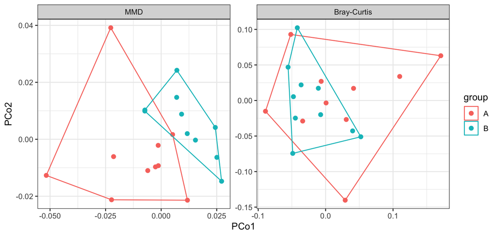

```r
pcoa <- do.call(rbind, lapply(names(D), function(k) {
    data.frame(samples, cmdscale(D[[k]], k = 2), distance = k)
}))
pcoa$distance <- factor(pcoa$distance, names(D))
hull <- do.call(rbind, lapply(split(pcoa, ~ distance + group), function(d) {
    d[chull(d$X1, d$X2), ]
}))
ggplot(pcoa, aes(X1, X2, colour = group)) +
    geom_point(size = 2) +
    geom_polygon(data = hull, fill = NA) +
    facet_wrap(~distance, scales = "free") +
    labs(x = "PCo1", y = "PCo2") +
    theme_bw()
```

MMD separates the groups and Bray-Curtis does not. Bray-Curtis compares accessions, and each GrpE protein is in one sample only, so to it the enrichment is noise; MMD credits the ten GrpE proteins for being close in the embedding space.

# Protein bins and differential abundance

`protein_similarity()` joins two proteins when their alignment has an E-value of at most 0.01, weighting the edge by their predicted TM-score. `bin_proteins()` splits that graph by Markov clustering and returns each protein’s bin (`membership`), the proteins of each bin (`clusters`) and each bin’s medoid (`representatives`).

```r
S <- protein_similarity(proteins) # aligns every pair: quadratic in proteins
bins <- bin_proteins(S)
table(size = lengths(bins$clusters))
```

```
#> size
#>  1  2  4 11
#> 89  3  1  1
```

The GrpE labels were not used to build the bins, so they can score them: coherence is the share of the GrpE proteins in the bin that holds most of them, and purity the share of that bin’s proteins that are GrpE.

```r
grpe <- annotation$protein[annotation$role == "GrpE"]
grpe_bin <- names(which.max(table(bins$membership[grpe])))
c(coherence = mean(bins$membership[grpe] == grpe_bin),
    purity = mean(bins$clusters[[grpe_bin]] %in% grpe))
```

```
#> coherence    purity
#> 1.0000000 0.9090909
```

`bin_glom()` sums the counts within each bin. Any differential abundance method can take the bin table; here a linear model per bin on the centred log-ratio (CLR) of the counts, with a pseudo count of 1, and Benjamini-Hochberg adjustment. LFC is the log2 fold change of group A over group B. Bins with p < 0.05:

```r
bin_counts <- bin_glom(counts, bins) # samples x bins
clr <- log2(bin_counts + 1)
clr <- clr - rowMeans(clr)
group <- factor(samples$group, c("B", "A"))
fit <- t(apply(clr, 2, function(y) {
    summary(lm(y ~ group))$coefficients["groupA", c("Estimate", "Pr(>|t|)")]
}))
res <- data.frame(bin = rownames(fit), LFC = fit[, 1], p = fit[, 2],
    q = p.adjust(fit[, 2], "BH"))
res <- res[res$p < 0.05, ]
knitr::kable(transform(res, LFC = round(LFC, 2),
    p = formatC(p, format = "g", digits = 2), q = formatC(q, format = "g", digits = 2)),
    row.names = FALSE)
```

| bin | LFC | p | q |
| --- | --- | --- | --- |
| bin1 | 3.76 | 5.7e-14 | 5.4e-12 |
| bin53 | -0.67 | 0.0057 | 0.27 |
| bin56 | 0.53 | 0.015 | 0.35 |
| bin74 | -0.68 | 0.011 | 0.34 |

The GrpE bin, bin1, stands out, although each GrpE protein is abundant in one sample only.

# Notes

`protein_similarity()` aligns every pair and `sample_mmd()` holds a protein-by-protein kernel, so on real data use the proteins identified in your samples, never a whole search database: 20,000 proteins take about 3 GB. `protein_similarity()` parallelises with `n_cores`. Structural similarity does not guarantee shared function: the GrpE bin also holds a DnaK protein, GrpE’s HSP-70 partner.

# References

- Aitchison (1982). The statistical analysis of compositional data. https://doi.org/10.1111/j.2517-6161.1982.tb01195.x.
- Anderson (2001). A new method for non-parametric multivariate analysis of variance. https://doi.org/10.1111/j.1442-9993.2001.01070.pp.x.
- Galperin et al. (2025). COG database update 2024. https://doi.org/10.1093/nar/gkae983.
- Gretton et al. (2012). A Kernel Two-Sample Test. https://jmlr.org/papers/v13/gretton12a.html.
- Hamamsy et al. (2024). Protein remote homology detection and structural alignment using deep learning. https://doi.org/10.1038/s41587-023-01917-2.
- Karlin and Altschul (1990). Methods for assessing the statistical significance of molecular sequence features by using general scoring schemes. https://doi.org/10.1073/pnas.87.6.2264.
- Steinegger and Söding (2017). MMseqs2 enables sensitive protein sequence searching for the analysis of massive data sets. https://doi.org/10.1038/nbt.3988.
- van Dongen (2000). Graph clustering by flow simulation. PhD thesis, University of Utrecht.